# Exercise2

We will use two data sets: `srtm` and `zion`. The first one is an elevation raster object for the Zion National Park area, and the second one is an sf object with polygons representing borders of the Zion National Park.

```r
srtm <- raster(system.file("raster/srtm.tif", package = "spDataLarge"))
zion <- read_sf(system.file("vector/zion.gpkg", package = "spDataLarge"))

# Additionally, the last exercise (IV) will used the masked version of the `lc_data` dataset.

study_area <- read_sf("data/study_area.gpkg")
lc_data <- raster("data/example_landscape.tif")
lc_data_masked <- mask(crop(lc_data, study_area), study_area)
```

## Exercise I

### 1

Display the `zion` object and view its structure. What can you say about the content of this file? What type of data does it store? What is the coordinate system used? How many attributes does it contain? What is its geometry?

```r
zion
```

```
## Simple feature collection with 1 feature and 11 fields
## geometry type:  POLYGON
## dimension:      XY
## bbox:           xmin: 302903.1 ymin: 4112244 xmax: 334735.5 ymax: 4153087
## projected CRS:  UTM Zone 12, Northern Hemisphere
## # A tibble: 1 x 12
##   UNIT_CODE GIS_Notes UNIT_NAME DATE_EDIT  STATE REGION GNIS_ID UNIT_TYPE
##   <chr>     <chr>     <chr>     <date>     <chr> <chr>  <chr>   <chr>
## 1 ZION      Lands - ~ Zion Nat~ 2017-06-22 UT    IM     1455157 National~
## # ... with 4 more variables: CREATED_BY <chr>, METADATA <chr>, PARKNAME <chr>,
## #   geom <POLYGON [m]>
```

```r
str(zion)
```

```
## sf [1 x 12] (S3: sf/tbl_df/tbl/data.frame)
##  $ UNIT_CODE : chr "ZION"
##  $ GIS_Notes : chr "Lands - http://landsnet.nps.gov/tractsnet/documents/ZION/Metadata/zion_metadata.xml"
##  $ UNIT_NAME : chr "Zion National Park"
##  $ DATE_EDIT : Date[1:1], format: "2017-06-22"
##  $ STATE     : chr "UT"
##  $ REGION    : chr "IM"
##  $ GNIS_ID   : chr "1455157"
##  $ UNIT_TYPE : chr "National Park"
##  $ CREATED_BY: chr "Lands"
##  $ METADATA  : chr "https://irma.nps.gov/App/Reference/Profile/2181118#Zion National Monument"
##  $ PARKNAME  : chr "Zion"
##  $ geom      :sfc_POLYGON of length 1; first list element: List of 1
##   ..$ : num [1:622, 1:2] 314945 314804 314331 314337 314345 ...
##   ..- attr(*, "class")= chr [1:3] "XY" "POLYGON" "sfg"
##  - attr(*, "sf_column")= chr "geom"
##  - attr(*, "agr")= Factor w/ 3 levels "constant","aggregate",..: NA NA NA NA NA NA NA NA NA NA ...
##   ..- attr(*, "names")= chr [1:11] "UNIT_CODE" "GIS_Notes" "UNIT_NAME" "DATE_EDIT" ...
```

### Answers

It contains one entry, that is the whole polygon (vector) that outlines Zion National Park. This entry / feature also has metadata about the name, date edited, bounding box, the US state the park resides in and stuff like that. The shape is specified in 2D with XY coordinates and has 11 fields, not counting the geometry of the shape

### 2

Display the `srtm` object and view its structure. What can you say about the content of this file? What type of data does it store? What is the coordinate system used? How many attributes does it contain? How many dimensions does it have? What is the data resolution?

```r
srtm
```

```
## class      : RasterLayer
## dimensions : 457, 465, 212505  (nrow, ncol, ncell)
## resolution : 0.0008333333, 0.0008333333  (x, y)
## extent     : -113.2396, -112.8521, 37.13208, 37.51292  (xmin, xmax, ymin, ymax)
## crs        : +proj=longlat +datum=WGS84 +no_defs
## source     : D:/R-4.0.3/library/spDataLarge/raster/srtm.tif
## names      : srtm
## values     : 1024, 2892  (min, max)
```

```r
str(srtm)
```

```
## Formal class 'RasterLayer' [package "raster"] with 12 slots
##   ..@ file    :Formal class '.RasterFile' [package "raster"] with 13 slots
##   .. .. ..@ name        : chr "D:\\R-4.0.3\\library\\spDataLarge\\raster\\srtm.tif"
##   .. .. ..@ datanotation: chr "INT2U"
##   .. .. ..@ byteorder   : chr "little"
##   .. .. ..@ nodatavalue : num -Inf
##   .. .. ..@ NAchanged   : logi FALSE
##   .. .. ..@ nbands      : int 1
##   .. .. ..@ bandorder   : chr "BIL"
##   .. .. ..@ offset      : int 0
##   .. .. ..@ toptobottom : logi TRUE
##   .. .. ..@ blockrows   : int 8
##   .. .. ..@ blockcols   : int 465
##   .. .. ..@ driver      : chr "gdal"
##   .. .. ..@ open        : logi FALSE
##   ..@ data    :Formal class '.SingleLayerData' [package "raster"] with 13 slots
##   .. .. ..@ values    : logi(0)
##   .. .. ..@ offset    : num 0
##   .. .. ..@ gain      : num 1
##   .. .. ..@ inmemory  : logi FALSE
##   .. .. ..@ fromdisk  : logi TRUE
##   .. .. ..@ isfactor  : logi FALSE
##   .. .. ..@ attributes: list()
##   .. .. ..@ haveminmax: logi TRUE
##   .. .. ..@ min       : num 1024
##   .. .. ..@ max       : num 2892
##   .. .. ..@ band      : int 1
##   .. .. ..@ unit      : chr ""
##   .. .. ..@ names     : chr "srtm"
##   ..@ legend  :Formal class '.RasterLegend' [package "raster"] with 5 slots
##   .. .. ..@ type      : chr(0)
##   .. .. ..@ values    : logi(0)
##   .. .. ..@ color     : logi(0)
##   .. .. ..@ names     : logi(0)
##   .. .. ..@ colortable: logi(0)
##   ..@ title   : chr(0)
##   ..@ extent  :Formal class 'Extent' [package "raster"] with 4 slots
##   .. .. ..@ xmin: num -113
##   .. .. ..@ xmax: num -113
##   .. .. ..@ ymin: num 37.1
##   .. .. ..@ ymax: num 37.5
##   ..@ rotated : logi FALSE
##   ..@ rotation:Formal class '.Rotation' [package "raster"] with 2 slots
##   .. .. ..@ geotrans: num(0)
##   .. .. ..@ transfun:function ()
##   ..@ ncols   : int 465
##   ..@ nrows   : int 457
##   ..@ crs     :Formal class 'CRS' [package "sp"] with 1 slot
##   .. .. ..@ projargs: chr "+proj=longlat +datum=WGS84 +no_defs"
##   ..@ history : list()
##   ..@ z       : list()
```

### Answers

The file is a raster with 457*465 pixels and a resolution of ~0.0008. From the file we can also tell that the CRS is a 3D-model as well as the raster’s bounding box. The raster has 12 main attributes (with sub-attributes) that also tell us about where the file resides, if the image is rotated, which colours the legend uses et cetera.

## Exercise II

### 1

Reproject the `srtm` dataset into the coordinate reference system used in the `zion` object. Create a new object `srtm2` Vizualize the results using the `plot()` function.

```r
srtm2 <- srtm

srtm2 <- projectRaster(srtm2, crs = st_crs(zion)$proj4string)
```

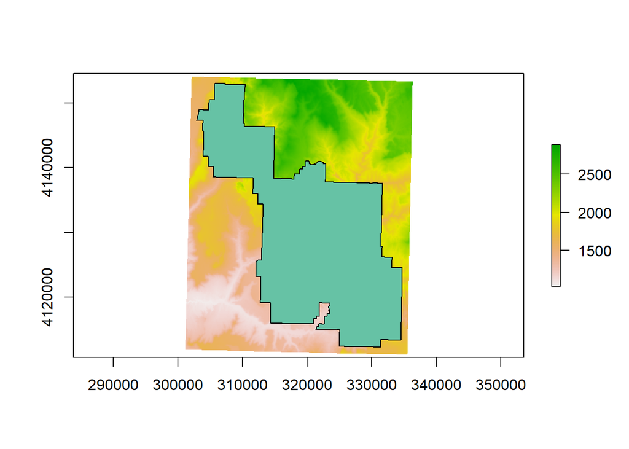

```r
plot(srtm2)
plot(zion, add = TRUE)
```

### 2

Reproject the `zion` dataset into the coordinate reference system used in the `srtm` object. Create a new object `zion2` Vizualize the results using the `plot()` function.

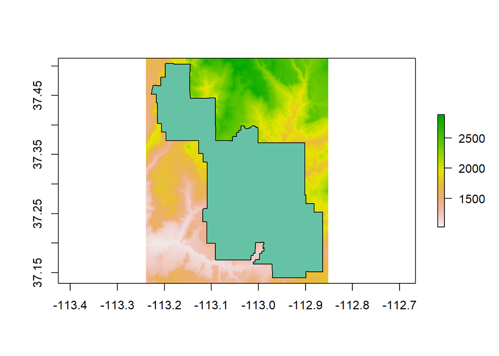

```r
zion2 <- zion

zion2 <- st_transform(zion, crs = crs(srtm, asText = TRUE))

plot(srtm)
plot(zion2, add = TRUE)
```